# Using the Facebook API

**Emma Lurie**

Getting data from Facebook is not trivial, Facebook has restrictions on what data to collect and how. We'll have to start by using our own FB accounts to create an app and get its ID and secret. While usually the next step is to use these to generate a so-called OAuth token, we'll skip that step and combine appId + appSecret in the URL to serve as an identification token.

You shouldn't publish the app secret on the open Web, since others might use it to "impersonate" your app. Thus, once you have completed this notebook and displayed all results, replace the `appSecret` value with a dummy one.

**Credits:** This notebook was based on Max Woolf's ["How to scrape data from Facebook" tutorial](https://github.com/minimaxir/facebook-page-post-scraper/blob/master/examples/how_to_build_facebook_scraper.ipynb).

Eni Mustafaraj made several modifications, such as replacing the `urllib2` library with the better performing `requests`, as well as simplifying the code to make it more "Pythonic". Some data analysis exercises were also added.

```python
import requests
import json
```

Perform this step before moving on.

```python
appId = "APP_ID"
appSecret = "SECRET"
accessToken = "{}|{}".format(appId, appSecret)
#print accessToken
```

The page id is part of the Facebook URL for an organization, personality, etc.

```python
pageId = 'WellesleyCollege'
```

```python
def testFacebookPageData(pageId, accessToken):
    "simple function to test that we can talk to Facebook"

    base = "https://graph.facebook.com/v2.4/{page}/?access_token={token}"
    url = base.format(page=pageId, token=accessToken)
    resp = requests.get(url)
    if resp.status_code == 200:
        data = json.loads(resp.text) #
    return data

data = testFacebookPageData(pageId, accessToken)
```

Let's try another page:

```python
testFacebookPageData("nytimes", accessToken)
```

```
{u'id': u'5281959998', u'name': u'The New York Times'}
```

Find the pageId of a page that you like on FaceBook and run the function `testFacebookPageData` for it.

```python
testFacebookPageData("dancingwinniethepooh", accessToken)
```

```
{u'id': u'1176770705769833', u'name': u'Dancing Winnie-The-Pooh'}
```

#### So the response from the request is the an id number that fb uses to represent the page, and the full name of the page

## Dealing with network errors

When retrieving data automatically, often we will run into network errors, such as the **Internal Error 500**, which is a server error over which we don't have control. In that case, we want our code to be robust and keep trying.

```python
import datetime

def request_until_succeed(url):
    success = False
    while success is False:
        try:
            resp = requests.get(url)
            if resp.status_code == 200:
                success = True
        except Exception, e:
            print e
            time.sleep(5)
            print "Error timestamp:", datetime.datetime.now()

    return resp.text
```

#### Testing out request_until_succeed; the output is in the same format as testFacebookPageData

```python
pageId = "nytimes"
base = "https://graph.facebook.com/v2.4/{page}/?access_token={token}"
url = base.format(page=pageId, token=accessToken)
print request_until_succeed(url)
```

```
{"name":"The New York Times","id":"5281959998"}
```

```python
pageId = "WellesleyCollege"
```

## Read the feed

The function `testFacebookPageData` we saw only returned the ID and complete name of a page. Now we want to retrieve the feed content. For that, we add 'feed' in the URL base (see example in the code below).

```python
def testFacebookPageData(pageId, accessToken):
    "simple function to test that we can talk to Facebook"

    base = "https://graph.facebook.com/v2.4/{page}/feed/?access_token={token}"
    url = base.format(page=pageId, token=accessToken)
    resp = requests.get(url)
    if resp.status_code == 200:
        data = json.loads(resp.text) #
    return data

# Print some results
result = testFacebookPageData(pageId, accessToken)
print "total items =", len(result['data']) # only the list of
twoStatuses = result['data'][:2]
print json.dumps(twoStatuses, indent=2, sort_keys=True) # format JSON to look nicely
```

```
total items = 25
[
  {
    "created_time": "2017-02-03T15:01:26+0000",
    "id": "24012621919_10154028816051920",
    "message": "Abigail Harrison'19 aka Astronaut Abby started a nonprofit called The Mars Generation, whose mission is to excite young people about STEAM study and space exploration. In November, she was named to The Huffington Post's \"20 Under 20: The Next Generation of STEAM Pioneers.\""
  },
  {
    "created_time": "2017-02-02T14:50:52+0000",
    "id": "24012621919_10154025309566920",
    "message": "\"I learned to form friendships with women that transcended any competition. I found role models. For four blissful years I did not see math and physics as male dominated activities.\" -Persis Drell \u201977 P\u201916 on her Wellesley experience"
  }
]
```

### Get more data from the feed

The entries we're getting from the feed contain minimal information (only a few fields). We'll modify the URL to request for more fields, especially information such as number of likes, comments, and shares. For the fields of *likes* and *comments* we can also request a summary of list of users who participated in the action. By providing a value for the `limit` function, we can control the number of users returned for these two fields. The field *shared* only displays the total number of counts, not a list of users (I got an error message saying: "Subfields are not supported by shares").

```python
def getFacebookPageFeedData(pageId, accessToken, numStatuses):
    "Function to retrieve a specific number of statuses from the feed, with more fields per status."

    # construct the URL string
    base = "https://graph.facebook.com/v2.4/{node}/feed/?access_token={token}"
    firstHalf = base.format(node=pageId, token=accessToken)
    secondHalf = "&fields=message,link,created_time,type,name,id,likes.limit(1).summary(true),comments.limit(1).summary(true),shares&limit="
    url = firstHalf + secondHalf + str(numStatuses)
    print url # to test on the browser, in case it doesn't work
    # retrieve data using the helper function that deals with connection errors
    data = json.loads(request_until_succeed(url))

    return data

# retrieve two statuses, and read the second one (which has shares)
testStatus = getFacebookPageFeedData(pageId, accessToken, 2)["data"][1]
print json.dumps(testStatus, indent=2, sort_keys=True)
```

```
https://graph.facebook.com/v2.4/WellesleyCollege/feed/?access_token=222723924855615|dd5a07aa9b8cf662f6b7e4d496b7d1d9&fields=message,link,created_time,type,name,id,likes.limit(1).summary(true),comments.limit(1).summary(true),shares&limit=2
{
  "comments": {
    "data": [
      {
        "created_time": "2017-02-02T15:28:13+0000",
        "from": {
          "id": "1501753836515970",
          "name": "Liza Moran"
        },
        "id": "10154025309566920_10154025376771920",
        "message": "Congratulations, Persis!"
      }
    ],
    "paging": {
      "cursors": {
        "after": "MTAZD",
        "before": "MTAZD"
      },
      "next": "https://graph.facebook.com/v2.8/24012621919_10154025309566920/comments?access_token=222723924855615%7Cdd5a07aa9b8cf662f6b7e4d496b7d1d9&summary=true&limit=1&after=MTAZD"
    },
    "summary": {
      "can_comment": false,
      "order": "ranked",
      "total_count": 10
    }
  },
  "created_time": "2017-02-02T14:50:52+0000",
  "id": "24012621919_10154025309566920",
  "likes": {
    "data": [
      {
        "id": "10100317053708642",
        "name": "Scarlett Loomas"
      }
    ],
    "paging": {
      "cursors": {
        "after": "MTAxMDAzMTcwNTM3MDg2NDIZD",
        "before": "MTAxMDAzMTcwNTM3MDg2NDIZD"
      },
      "next": "https://graph.facebook.com/v2.8/24012621919_10154025309566920/likes?access_token=222723924855615%7Cdd5a07aa9b8cf662f6b7e4d496b7d1d9&summary=true&limit=1&after=MTAxMDAzMTcwNTM3MDg2NDIZD"
    },
    "summary": {
      "can_like": false,
      "has_liked": false,
      "total_count": 420
    }
  },
  "link": "http://wellesley.io/GDYy3I",
  "message": "\"I learned to form friendships with women that transcended any competition. I found role models. For four blissful years I did not see math and physics as male dominated activities.\" -Persis Drell \u201977 P\u201916 on her Wellesley experience",
  "name": "Persis Drell \u201977 P\u201916 Takes Office as Stanford University Provost",
  "shares": {
    "count": 22
  },
  "type": "link"
}
```

## Parsing each post

Each post may contain more information than we want or some posts will miss some information we expect. This function will try to "normalize" the data, so that we can put them on a table.  
The code below contains a Python idiom that you might not be familiar with, involving the use of if / else in an assignment statement. That is similar to the [ternary operator in Java](http://alvinalexander.com/java/edu/pj/pj010018), in case you've seen it.

```python
import datetime

def processFacebookPageFeedStatus(status):
    '''returns a dictionary summarizing the data from a speciic status'''
    statusDct = {} # empty dict to store the fields

    statusDct['id'] = status['id']
    statusDct['message'] = status.get('message', '').encode('utf-8') # deal with unicode values
    statusDct['linkName'] = status.get('name', '').encode('utf-8')
    statusDct['statusType'] = status['type']
    statusDct['link'] = status.get('link', '')

    # Time needs special care since a) it's in UTC and
    # b) it's not easy to use in statistical programs.

    pubDate = datetime.datetime.strptime(status['created_time'],'%Y-%m-%dT%H:%M:%S+0000')
    pubDate = pubDate + datetime.timedelta(hours=-5) # EST
    pubDate = pubDate.strftime('%Y-%m-%d %H:%M:%S') # best time format for spreadsheet programs
    statusDct['datetime'] = pubDate

    # Nested items require chaining dictionary keys.
    # Notice the use of if/else in these statements. They mimic the "ternary" operation you might know from Java
    statusDct['likes'] = 0 if 'likes' not in status.keys() else status['likes']['summary']['total_count']
    statusDct['comments'] = 0 if 'comments' not in status.keys() else status['comments']['summary']['total_count']
    statusDct['shares'] = 0 if 'shares' not in status.keys() else status['shares']['count']

    return statusDct

parsedStatus = processFacebookPageFeedStatus(testStatus)
print parsedStatus
```

```
{'comments': 10, 'datetime': '2017-02-02 09:50:52', 'link': u'http://wellesley.io/GDYy3I', 'likes': 420, 'shares': 22, 'linkName': 'Persis Drell \xe2\x80\x9977 P\xe2\x80\x9916 Takes Office as Stanford University Provost', 'message': '"I learned to form friendships with women that transcended any com…
```

## Putting all together: collecting the entire feed

The following function will try to collect all posts for a given page. Facebook let's you get 100 posts at a time, thus, we'll keep sending requests until we get all posts. In order to do that, we'll exploit the fact that in every response, Facebook includes the URL for the next bunch of 100 posts.

```python
def scrapeFacebookPageFeedStatus(pageId, accessToken):

    allStatuses = []

    hasNextPage = True
    numProcessed = 0   # keep a count on how many we've processed
    scrapeStartTime = datetime.datetime.now()

    print "Scraping {page} Facebook Page: {time}\n".format(page=pageId,
                                                           time=scrapeStartTime)

    statuses = getFacebookPageFeedData(pageId, accessToken, 100)

    while hasNextPage:
        for status in statuses['data']:
            statusDct = processFacebookPageFeedStatus(status)
            allStatuses.append(statusDct)

            # output progress occasionally to make sure code is not stalling
            numProcessed += 1
            if numProcessed % 500 == 0:
                print "{count} Statuses Processed: {time}".format(count=numProcessed,
                                                                  time=datetime.datetime.now())
        # if there is no next page, we're done.
        if 'paging' in statuses:
            statuses = json.loads(request_until_succeed(statuses['paging']['next']))
        else:
            hasNextPage = False


    print "\nDone!\n{count} Statuses Processed in {time}".format(count=numProcessed,
                                                                  time=datetime.datetime.now() - scrapeStartTime)

    return allStatuses

allStatuses = scrapeFacebookPageFeedStatus(pageId, accessToken)
print "We stored {count} statuses for {page}".format(count=len(allStatuses), page=pageId)
```

```
Scraping WellesleyCollege Facebook Page: 2017-02-05 10:36:49.054217

https://graph.facebook.com/v2.4/WellesleyCollege/feed/?access_token=222723924855615|dd5a07aa9b8cf662f6b7e4d496b7d1d9&fields=message,link,created_time,type,name,id,likes.limit(1).summary(true),comments.limit(1).summary(true),shares&limit=100
500 Statuses Processed: 2017-02-05 10:36:57.047503
1000 Statuses Processed: 2017-02-05 10:37:02.710211
1500 Statuses Processed: 2017-02-05 10:37:09.059781
2000 Statuses Processed: 2017-02-05 10:37:14.465979

Done!
2287 Statuses Processed in 0:00:28.903750
We stored 2287 statuses for WellesleyCollege
```

```python
# store results
json.dump(allStatuses, open("wellesleyFacebookPosts.json", "w"))
```

```python
import collections
```

```python
print allStatuses[0].keys()
```

```
['comments', 'datetime', 'link', 'likes', 'shares', 'linkName', 'message', 'statusType', 'id']
```

```python
def mostRepresentativeWords(date):
    "return representative words with their counts"
    wordList = []
    for entry in allStatuses:
        if entry['datetime'].split()[0] == date:
            for word in entry['message'].split():
                if len(word) > 3: wordList.append(word)
    #print wordList
    return collections.Counter(wordList).most_common(5)
```

Let's try it out with different dates:

```python
print mostRepresentativeWords("2016-05-27")
```

```
[('#Wellesley2016', 4), ('Chow', 4), ('Commencement', 4), ('Wang', 4), ('Lulu', 4)]
```

```python
mostRepresentativeWords("2016-11-08")
```

```
[('#WellesleyWatches', 3),
 ('results', 2),
 ('election', 2),
 ('students', 2),
 ('here', 2)]
```

```python
mostRepresentativeWords("2016-09-30")
```

```
[('#WellesleyPrez', 3),
 ('Inauguration', 3),
 ('Ceremony', 1),
 ('forget', 1),
 ('two-day', 1)]
```

# During the campaign, how does Trump's language on FB compare to Hillary's?

```python
pageId = 'DonaldTrump'
trumpStatuses = scrapeFacebookPageFeedStatus(pageId, accessToken)
```

```
Scraping DonaldTrump Facebook Page: 2017-02-05 10:37:18.198389

https://graph.facebook.com/v2.4/DonaldTrump/feed/?access_token=222723924855615|dd5a07aa9b8cf662f6b7e4d496b7d1d9&fields=message,link,created_time,type,name,id,likes.limit(1).summary(true),comments.limit(1).summary(true),shares&limit=100
500 Statuses Processed: 2017-02-05 10:37:33.085261
1000 Statuses Processed: 2017-02-05 10:37:50.052747
1500 Statuses Processed: 2017-02-05 10:38:06.659762
2000 Statuses Processed: 2017-02-05 10:38:25.580329
2500 Statuses Processed: 2017-02-05 10:38:46.197674
3000 Statuses Processed: 2017-02-05 10:39:05.751931
3500 Statuses Processed: 2017-02-05 10:39:21.607694
4000 Statuses Processed: 2017-02-05 10:39:36.501900
4500 Statuses Processed: 2017-02-05 10:39:47.612137

Done!
4921 Statuses Processed in 0:02:34.650938
```

```python
pageId = 'hillaryclinton'
hillStatuses = scrapeFacebookPageFeedStatus(pageId, accessToken)
```

```
Scraping hillaryclinton Facebook Page: 2017-02-05 10:44:50.863488

https://graph.facebook.com/v2.4/hillaryclinton/feed/?access_token=222723924855615|dd5a07aa9b8cf662f6b7e4d496b7d1d9&fields=message,link,created_time,type,name,id,likes.limit(1).summary(true),comments.limit(1).summary(true),shares&limit=100
500 Statuses Processed: 2017-02-05 10:45:05.061243
1000 Statuses Processed: 2017-02-05 10:45:20.610610
1500 Statuses Processed: 2017-02-05 10:45:35.502560
2000 Statuses Processed: 2017-02-05 10:45:50.536088
2500 Statuses Processed: 2017-02-05 10:46:04.270904
3000 Statuses Processed: 2017-02-05 10:46:17.829665
3500 Statuses Processed: 2017-02-05 10:46:32.867062
4000 Statuses Processed: 2017-02-05 10:46:46.130399

Done!
4119 Statuses Processed in 0:01:59.571636
```

#### Only look at posts before the election and after Trump declared his candidacy

```python
pe_trump = [] # pre-election trump posts
for status in trumpStatuses:
    date = status['datetime'].split()[0]
    if date <= '2016-11-08' and date>= '2015-06-16':
        pe_trump.append(status)

pe_hill = [] # pre-election hillary posts
for status in hillStatuses:
    date = status['datetime'].split()[0]
    if date <= '2016-11-08' and date>= '2015-06-16':
        pe_hill.append(status)
```

```python
print len(pe_trump)
print len(pe_hill)
```

```
3319
3891
```

## Textblob is a sentiment analyasis library I used to find the polarity of every message on each candidate's fb feed

```python
 from textblob import TextBlob
```

```python
import numpy as np
```

```python
trump_data = []
for status in pe_trump:
    trump_data.append((status['datetime'].split()[0],TextBlob(unicode(status['message'], errors='ignore')).sentiment.polarity))
```

```python
hill_data = []
for status in pe_hill:
    hill_data.append((status['datetime'].split()[0],TextBlob(unicode(status['message'], errors='ignore')).sentiment.polarity))
```

```python
'''creates a dictionary {date: average polarity on that day}'''
def oneNumADay(data):
    new_data = {}
    i = 0
    repeated_triples = []
    for i in range(len(data)):
        if i != 0:
            if data[i-1][0] == data[i][0]:
                if data[i-1][0] not in repeated_triples:
                    repeated_triples.append(data[i-1])
                repeated_triples.append(data[i])
            else:
                if len(repeated_triples) > 0:
                    new_data[data[i][0]] = averageDailyPolarity(repeated_triples)
                    repeated_triples = []
                else:
                    new_data[data[i][0]]= data[i][1]
    return new_data
```

```python
'''calculates average polarity on a certain day if there were multiple posts'''
def averageDailyPolarity(triples):
    polarities = []
    for triple in triples:
        polarities.append(triple[1])
    return np.mean(polarities)
```

```python
#print oneNumADay(trump_data)
trump_filtered = oneNumADay(trump_data)
hill_filtered = oneNumADay(hill_data)
```

```python
print len(trump_filtered)
print len(hill_filtered)
```

```
497
511
```

#### Fill in the days where no one posted

```python
d1 = datetime.date(2015,6,15)
d2 = datetime.date(2016,11,7)
diff = d2 - d1
```

```python
date_list = [(d1 + datetime.timedelta(i)).isoformat() for i in range(diff.days + 1)]
trump_pol = []
hill_pol = []
i = 0
for date in date_list:
    if date in trump_filtered:
        trump_pol.append(trump_filtered[date])
    else:
        trump_pol.append(0.0)

    if date in hill_filtered:
        hill_pol.append(hill_filtered[date])
    else:
        hill_pol.append(0.0)
```

#### A tangential interesting fact: Hillary's social media team made sure to post every day except 1 over their entire campaign... (511/512) Donald was (497/512)

```python
print len(hill_pol)
print len(trump_pol)
```

```
512
512
```

```python
import datetime
import plotly.plotly as py
import plotly.graph_objs as go
import plotly

plotly.tools.set_credentials_file(username='elurie', api_key='etkxcVLiDU9bjHDyEHtk')

candidates = ["Hillary Clinton", "Donald Trump"]


date_list = [(d1 + datetime.timedelta(i)).isoformat() for i in range(diff.days + 1)]

z = []

for candidate in candidates:
    new_row = []
    for date in date_list:
        new_row.append(np.random.poisson() )
    z.append(list(new_row))

z[0] = hill_pol
z[1] = trump_pol

data = [
    go.Heatmap(
        z=z,
        x=date_list,
        y=candidates,
        colorscale='Viridis',
    )
]

layout = go.Layout(
    title='Heatmap of the Polarity of Facebook Posts of Presidential Candidates',
    xaxis = dict(ticks='', nticks=36),
    yaxis = dict(ticks='' )
)

fig = go.Figure(data=data, layout=layout)
py.iplot(fig, filename='datetime-heatmap')
```

```
High five! You successfuly sent some data to your account on plotly. View your plot in your browser at https://plot.ly/~elurie/0 or inside your plot.ly account where it is named 'datetime-heatmap'
```

[interactive chart not shown]

# Final visualization of sentiment analysis using plotly

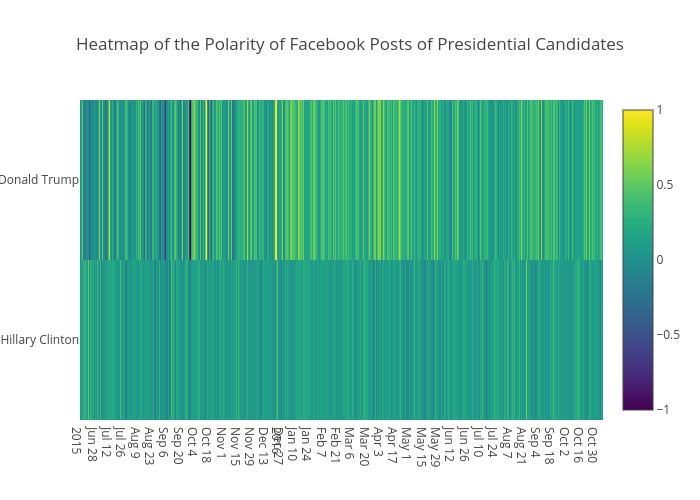

```python
from IPython.display import Image
Image("datetime-heatmap.png")
```

### Other experiments...

##### Filter out common words

```python
import csv
with open('common-english-words.csv', 'rb') as f:
    reader = csv.reader(f)
    filter_words = list(reader)[0]
```

#### Obama statuses (Obama has only 1799 posts to Trump's 4921)... Perhaps he was using the White House account?

```python
pageId = 'barackobama'
obamaStatuses = scrapeFacebookPageFeedStatus(pageId, accessToken)
```

```
Scraping barackobama Facebook Page: 2017-02-05 10:39:52.935661

https://graph.facebook.com/v2.4/barackobama/feed/?access_token=222723924855615|dd5a07aa9b8cf662f6b7e4d496b7d1d9&fields=message,link,created_time,type,name,id,likes.limit(1).summary(true),comments.limit(1).summary(true),shares&limit=100
500 Statuses Processed: 2017-02-05 10:40:07.564324
1000 Statuses Processed: 2017-02-05 10:40:23.450301
1500 Statuses Processed: 2017-02-05 10:40:37.093442

Done!
1799 Statuses Processed in 0:00:52.253209
```

```python
obamaWordList = []
for status in obamaStatuses:
     for word in status['message'].split():
            if len(word) > 3 and word not in filter_words:
                obamaWordList.append(word)
```

```python
print collections.Counter(obamaWordList).most_common(100)
```

```
[('Obama', 309), ('President', 234), ('\xe2\x80\x94President', 172), ('more', 140), ('health', 140), ('climate', 133), ('Watch', 122), ('weekly', 105), ('This', 99), ('time', 91), ('make', 90), ('Read', 89), ('care', 81), ('Share', 79), ('American', 76), ('Americans', 74), ('change', 72), ('fight', …
```